# Case Study two: Remuneration across Races and Regions

Author

Hadiya Cabdi

# Intro:

In this case study we will be examining subset of data from 1988 CPS(The Current Population Survey). It provides information about general activities and characteristics of U.S. labor force. It includes the following terms as columns: - Wages(in dollars) - Education(in years) - Experience(in years) - Black(indicator factor with yes and no) - SMSA(a factor with levels yes and no) - region(a factor with levels “MW”, “NE”, “S”, and “W”).

### Primary Goal:

The primary goal of this Case study is to answer:

- Q1: What is the pay gap between Black male workers and non-Black male workers in each geographic region?
- Q2: Does the magnitude of the pay gap between Black male and non-Black male workers differ across regions?

Our controls will be Education, and Experience to make the comparison fairer, and to potentially see the actual gap without other factors effecting it.

### Process:

First step is to always load our packages and run our data:

```r
library(car)
library(ggplot2)
library(tidyverse)
library(performance)
library(see)
library(Sleuth2) # install.packages("Sleuth2") in the R console if needed
CPS_1988_wages <- Sleuth2::ex1029
```

#### Wrangling data:

We will have to check for any NA variables that need to be cleaned out from the data, and we check that by:

```r
any(is.na(CPS_1988_wages))
```

```
[1] FALSE
```

This shows that the data doesn’t include any empty values.

### Check for Regression Assumptions:

To check if the model passes the Variance and regression assumption we will first create and additive model, assuming the wage gap is the same across all regions:

- The factor(Black) in our model is the indicator function which represents the wage gap, between black male workers and non black male workers.
- The factor(Region) controls for regional difference.

```r
test_additive <- lm(Wage ~ factor(Black) + factor(Region) + Education + Experience, data = CPS_1988_wages)
summary(test_additive)
```

[output not shown]

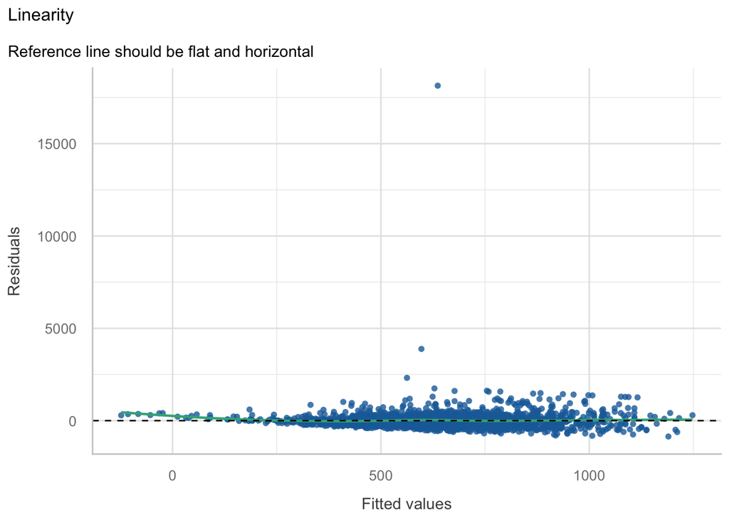

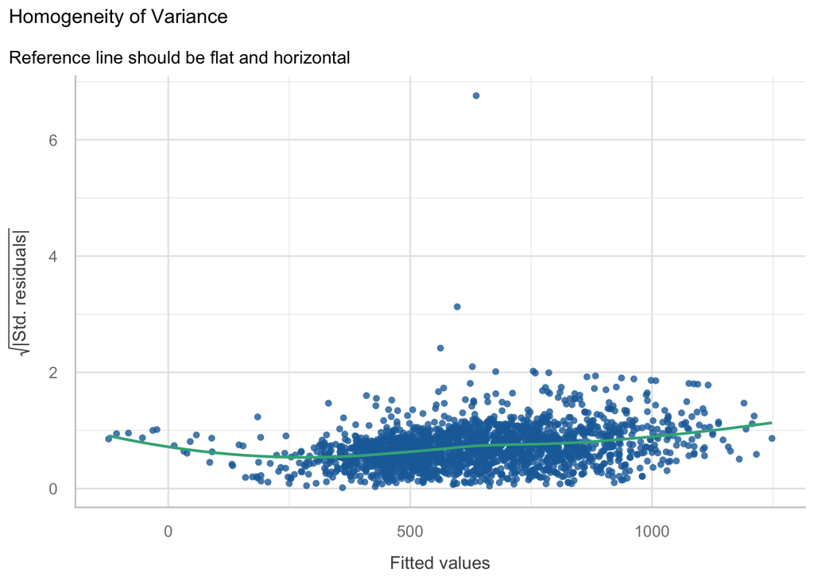

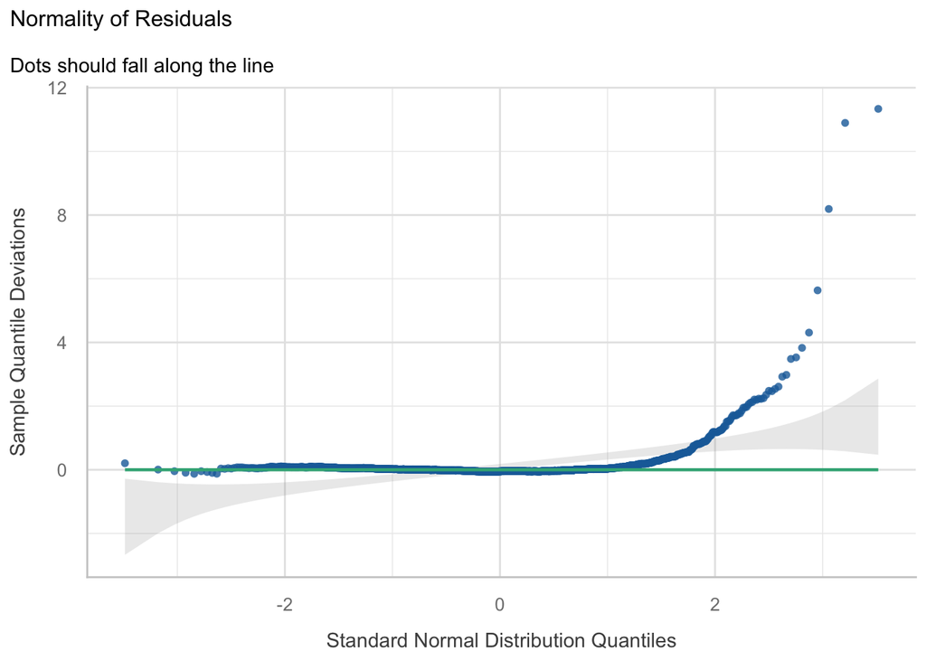

```r
check_all <- check_model(test_additive, check = c("linearity", "qq", "homogeneity"), panel = FALSE)
attr(check_all, "show_ci") <- FALSE
plot(check_all)
```

## Additive model:

We will first fit an additive multiple regression model while assuming the wage gap is the same across all regions. We apply the log function to satisfy regression assumptions such as constant variance. In other words without the log, the constant variance and regression assumption might fail, and very high wages could dominate the model. The statistical model below shows the breakdown of our additive model:

$$log(Wage)=β0+β1Black+β2Region+β3Education+β4Experience+ϵ$$

```r
model_add <- lm(log(Wage) ~ factor(Black) + factor(Region) + Education + Experience, data = CPS_1988_wages)
summary(model_add)
```

```
Call:
lm(formula = log(Wage) ~ factor(Black) + factor(Region) + Education +
    Experience, data = CPS_1988_wages)

Residuals:
    Min      1Q  Median      3Q     Max
-2.6566 -0.3030  0.0438  0.3517  3.6006

Coefficients:
                   Estimate Std. Error t value Pr(>|t|)
(Intercept)       4.4473460  0.0222449 199.927  < 2e-16 ***
factor(Black)No   0.2131223  0.0127313  16.740  < 2e-16 ***
factor(Region)NE  0.0605616  0.0097147   6.234 4.62e-10 ***
factor(Region)S  -0.0589539  0.0091429  -6.448 1.15e-10 ***
factor(Region)W   0.0042020  0.0099373   0.423    0.672
Education         0.0989679  0.0012070  81.994  < 2e-16 ***
Experience        0.0182769  0.0002811  65.021  < 2e-16 ***
---
Signif. codes:  0 '***' 0.001 '**' 0.01 '*' 0.05 '.' 0.1 ' ' 1

Residual standard error: 0.5357 on 25624 degrees of freedom
Multiple R-squared:  0.271, Adjusted R-squared:  0.2708
F-statistic:  1588 on 6 and 25624 DF,  p-value: < 2.2e-16
```

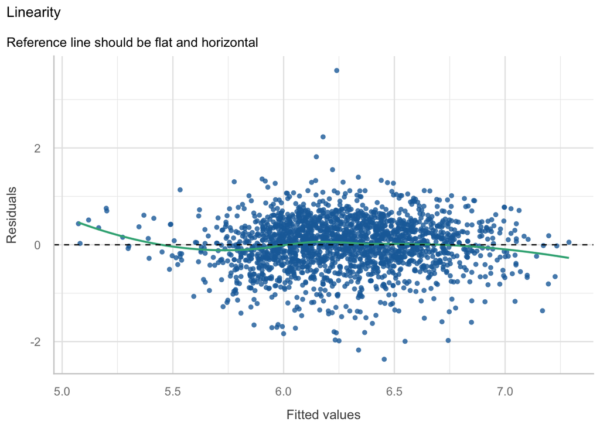

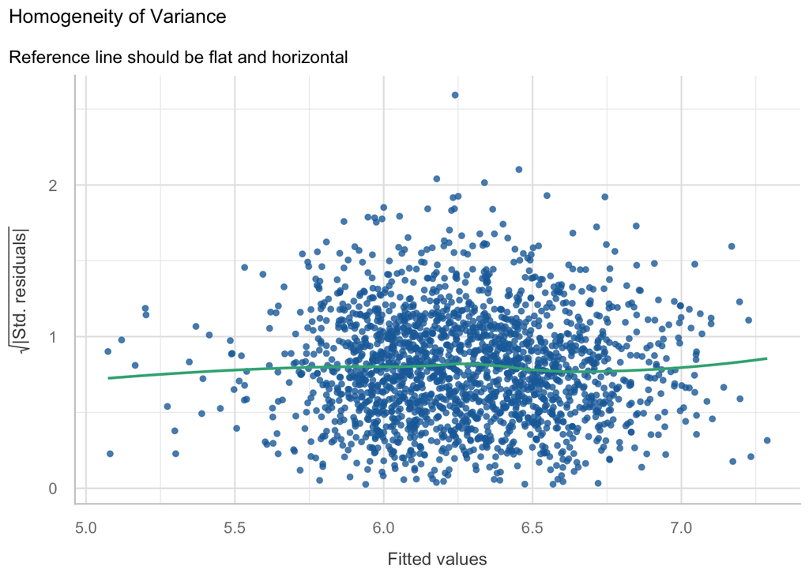

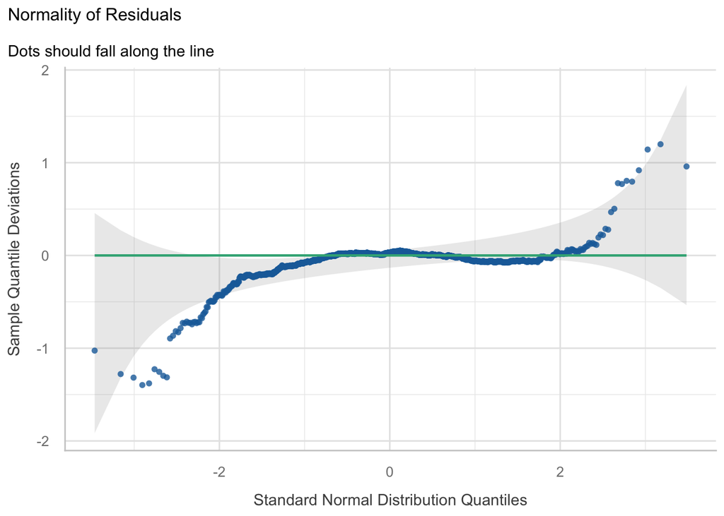

```r
check_all <- check_model(model_add, check = c("linearity", "qq", "homogeneity"), panel = FALSE)
attr(check_all, "show_ci") <- FALSE
plot(check_all)
```

After Variance, Linearity and QQNormal distribution check, the regression assumption seems much better, and outliers are not dragging the data to one side.

## Interpretation:

- Looking at our summary table we can see that we are missing factor(Black)Yes and the region MW. In this case they represent the baseline of our additive model. This translates to the baseline as Black workers in MW(Mid West). Now that we have all our stats from the summary table, we will have to compare the baseline(black workers in MW),
  $$b0$$
  to
  $$b1*BlackNO$$
  the non-black workers. The output for black workers(baseline) is
  $$log(Wage) = b0$$
  while for non black workers,
  $$log(Wage) = b0 + 0.2131$$
  which is from our summary table. We will have to solve for their difference in percentage:
  $$log(Wage_{nonBlack}) - log(Wage_{Black}) = 0.2131$$
  .

$$Wage_{nonBlack} / Wage_{Black} = e^{0.2131}$$
$$e^{0.2131} = 1.237$$
$$(1.237 - 1) = 0.237 = 23.7 %$$
It shows that non Black workers in the same region earn 24% more than Black Workers. Using confidence interval we can assess whether this percentage falls between the parameters of plausible population value.

```r
confint(model_add)
```

```
                       2.5 %      97.5 %
(Intercept)       4.40374481  4.49094720
factor(Black)No   0.18816831  0.23807625
factor(Region)NE  0.04152033  0.07960295
factor(Region)S  -0.07687457 -0.04103326
factor(Region)W  -0.01527559  0.02367961
Education         0.09660208  0.10133372
Experience        0.01772594  0.01882785
```

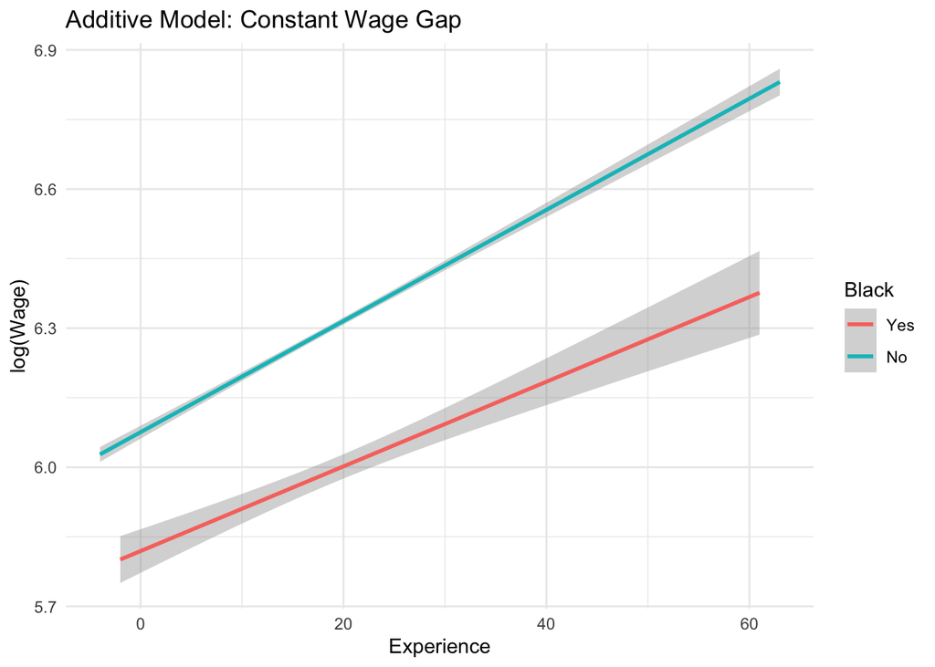

```r
library(ggplot2)

ggplot(CPS_1988_wages, aes(x = Experience, y = log(Wage), color = Black)) +
  geom_smooth(method = "lm", se = TRUE) +
  labs(title = "Additive Model: Constant Wage Gap") +
  theme_minimal()
```

#### Result for addative model:

Holding education, experience and region constant, non black male workers in the same region earn about 24% more than Black male Workers. The standard error associated with the wage gap (factor(Black)No) suggests a small variability which supports that non Black workers relatively get higher wages. In addition our Confidence interval calculations shows the wage gap between Black and non-Black workers is estimated to be between 21% and 27%, holding education, experience and region constant.Our percentage assumption of 24% falls in the range of 21% and 27& computed by the Confidence Interval.Thus non Black male workers in the same region earn 24% more than Black male workers.

## Interaction model:

Interaction model is important to allow the wage gap to vary by region. The statistical model equation would now include the interaction term(Black * Region) as shown below:

$$log(Wage)=β0+β1Black+β2Region+β3(Black×Region)+β4Education+β5Experience+ϵ$$

```r
model_inter <- lm(log(Wage) ~ factor(Black) * factor(Region) + Education + Experience, data = CPS_1988_wages)
summary(model_inter)
```

```
Call:
lm(formula = log(Wage) ~ factor(Black) * factor(Region) + Education +
    Experience, data = CPS_1988_wages)

Residuals:
    Min      1Q  Median      3Q     Max
-2.6555 -0.3022  0.0444  0.3511  3.5975

Coefficients:
                                   Estimate Std. Error t value Pr(>|t|)
(Intercept)                       4.4673281  0.0345950 129.132  < 2e-16 ***
factor(Black)No                   0.1928006  0.0306687   6.287  3.3e-10 ***
factor(Region)NE                  0.0571640  0.0420270   1.360  0.17379
factor(Region)S                  -0.0965601  0.0337339  -2.862  0.00421 **
factor(Region)W                   0.0415862  0.0504114   0.825  0.40942
Education                         0.0989226  0.0012075  81.926  < 2e-16 ***
Experience                        0.0182709  0.0002811  64.992  < 2e-16 ***
factor(Black)No:factor(Region)NE  0.0035277  0.0431955   0.082  0.93491
factor(Black)No:factor(Region)S   0.0417635  0.0350495   1.192  0.23345
factor(Black)No:factor(Region)W  -0.0382073  0.0514264  -0.743  0.45752
---
Signif. codes:  0 '***' 0.001 '**' 0.01 '*' 0.05 '.' 0.1 ' ' 1

Residual standard error: 0.5357 on 25621 degrees of freedom
Multiple R-squared:  0.2711,    Adjusted R-squared:  0.2709
F-statistic:  1059 on 9 and 25621 DF,  p-value: < 2.2e-16
```

```r
confint(model_inter)
```

```
                                       2.5 %      97.5 %
(Intercept)                       4.39951998  4.53513615
factor(Black)No                   0.13268819  0.25291306
factor(Region)NE                 -0.02521137  0.13953932
factor(Region)S                  -0.16268054 -0.03043970
factor(Region)W                  -0.05722308  0.14039539
Education                         0.09655588  0.10128927
Experience                        0.01771983  0.01882188
factor(Black)No:factor(Region)NE -0.08113788  0.08819324
factor(Black)No:factor(Region)S  -0.02693545  0.11046244
factor(Black)No:factor(Region)W  -0.13900600  0.06259149
```

The interaction model shows for factor(Black)No = 0.1928, which compares between the black vs non black workers in Midwest region only, due Midwest being the baseline region. Once we convert it, we will have:
$$(e^{0.1928} - 1)= 21.3%$$
This means: in the Midwest Non_Black workers earn about 21.3% more than Black_Workers. Compared to the estimate of the baseline, the standard error associated with the baseline is suggesting a small variability(it wouldn’t make substantial meaning since the baseline accounts for an individual with 0 experience and education). The range of plausible value for the wage gap between black workers and non black workers is between 0.133(14%) and 0.253(28.9%) for the interaction model. This supports that in the Midwest Non_Black workers can earn about 21.3% more than Black Workers.

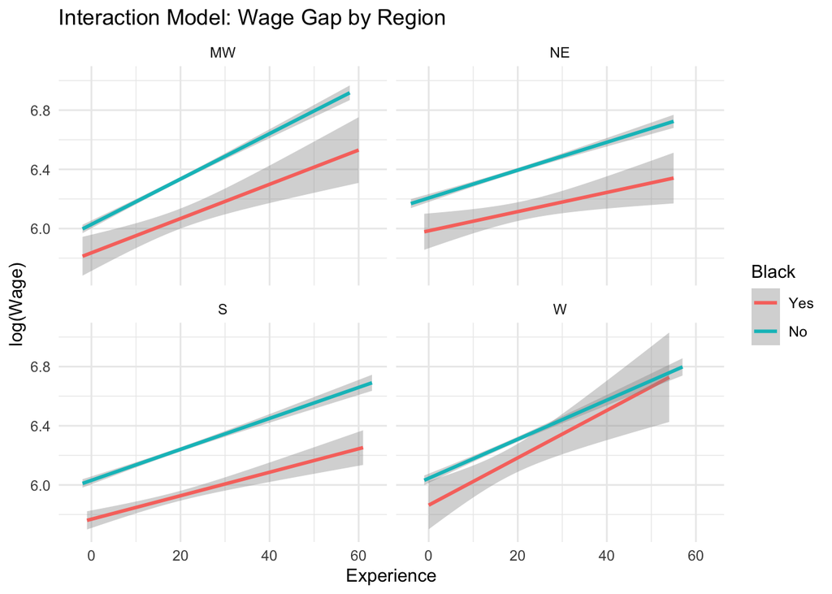

```r
ggplot(CPS_1988_wages, aes(x = Experience, y = log(Wage), color = Black)) +
  geom_smooth(method = "lm", se = TRUE) +
  facet_wrap(~ Region) +
  labs(title = "Interaction Model: Wage Gap by Region") +
  theme_minimal()
```

One of the important things this plot shows is that the teal line() representing the wage for non Black workers) is always on top of the red line of the black workers, which shows that there is definitely a wage gap between them and that non-black workers receive higher wages. The difference of the distance between the lines suggests that the wage gap may vary slightly across regions, but we will have to use F-test to see how significant that is.

#### Result for Interaction model: Actual Wage Gaps by Region:

To calculate for the actual wage gaps by region we will have to add our baseline wage to the rest of the wage gaps by region, as shown by the equation below:
$$Gap = factor(Black)No + factor(Black)No:factor(Region)$$
We will have these specific region wages:

```r
interaction_coef <- coef(model_inter)

MW <- interaction_coef["factor(Black)No"]

NE <- interaction_coef["factor(Black)No"] + interaction_coef["factor(Black)No:factor(Region)NE"]

S  <- interaction_coef["factor(Black)No"] + interaction_coef["factor(Black)No:factor(Region)S"]

W  <- interaction_coef["factor(Black)No"] + interaction_coef["factor(Black)No:factor(Region)W"]

(exp(c(MW=MW, NE=NE, S=S, W=W)) - 1) * 100
```

```
MW.factor(Black)No NE.factor(Black)No  S.factor(Black)No  W.factor(Black)No
          21.26410           21.69264           26.43575           16.71833
```